# Thesis Summary

Social Identity, Group Representation, and Unequal Responsiveness in the US and UK  
Zachary Dickson

### Hello there,

- In this presentation, I’ll highlight some of the key aspects of my thesis, including:
  - Format:
    - summary and substance of the four separate chapters
  - Methods/Data:
    - details of the method used throughout most of the thesis
    - political communication & elites’ online behavior
  - Key findings:
    - high-level substantive conclusions
    - empirical and methodological

#### Agenda-Setting and MPs’ Responsiveness Online

- Key questions:
  - Are UK MPs more responsive to different political groups on social media?
  - To which of the following groups – NGOs, the media and corporations – are MPs most responsive?
- Method:
  - Dynamic measure of daily attention to different salient issues (i.e. economy, health etc.)
  - Vector autoregression models to capture the effects of shifts in attention
- Key findings:
  - Corporations foreshadow the issue attention of Labour and Conservative MPs
  - NGOs have almost no ability to set the attention of MPs online
  - Media leads the attention of all actors on many issues (McCombs and Shaw 1972)

#### Social Class and Group Representation in Britain

- Key questions:
  - Do MPs’ educational backgrounds shape representation?
  - How does educational socialisation compare to occupational socialisation?
- Literature:
  - Social class and descriptive (under-) representation of working class voters (Carnes and Lupa 2015; O’Grady 2019)
  - Education shapes views of redistribution (Schakel and Van Der Pas 2021)
- Data:
  - Dynamic issue attention of UK MPs using social media and parliamentary speeches
  - Public issue priorities by MII surveys according to social grade
- Key findings
  - Oxbridge MPs give greater attention to the priorities of middle class voters
  - The “responsiveness gap” is similar when conditioning on education as with occupation in the UK

#### Group Representation and the Gender Divide

- Key questions:
  - Does gender shape the issues US and UK representatives emphasise online?
  - If so, are women representatives more responsive to women constituents? Country differences?
- Literature:
  - Discriptive representation and gendered patterns of resposiveness and congruence (Thomsen and Sanders 2020; Anzia and Berry 2011)
- Data:
  - US & UK representatives’ online messages on Twitter
  - Public priorities – US & UK MII surveys by gender
- Key findings
  - Women representatives are more responsive in both countries to issues prioritised by the national public
  - Women MPs in the UK prioritise women constituents, while women MCs in the US prioritise the national public

### The Limits of Group Loyalty in Congress

- Key questions:
  - How far will elites go to remain loyal to their group identities?
  - Does COVID-19 infection cause US MCs to reduce opposition to COVID-19 policies?
- Literature:
  - Partisan-motivated reasoning (Taber and Lodge 2006; Bisgaard 2015)
- Method:
  - US legislators’ revealed preferences on COVID-19 policies
  - NLP/Machine learning classification
- Key findings:
  - COVID-19 causes legislators to reduce their opposition to COVID-19 (revealed preferences)
  - Potential mechanisms – strategic shift & perceptions of danger

### Methods

Measuring MPs’ attention using social media data

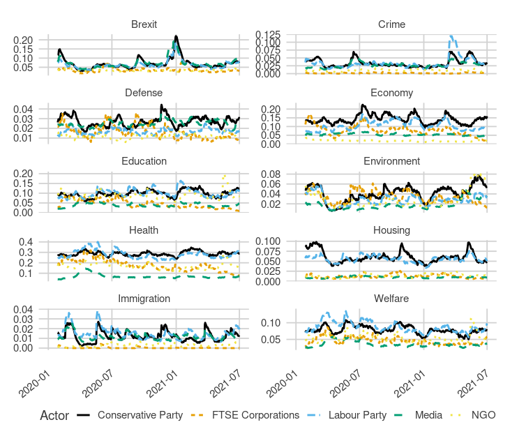

Issue attention as a proportion of attention to all issues (Baumgartner and Jones 2010)

Supervised vs. unsupervised methods (Mikolov et al. 2013)

Semi-supervised topic modelling

### Methods, Cont’d

Measuring public issue priorities using multiple surveys

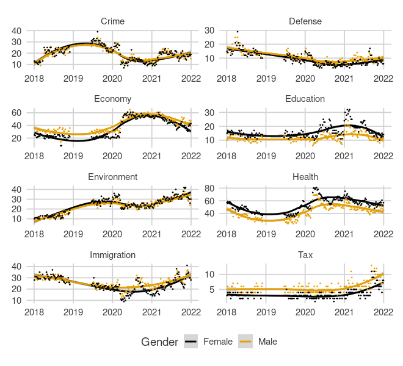

Repeated public surveys asking about MII (YouGov 2021)

Salience as percentage of population identifying an issue as the most important<sup>1</sup>

[^1]: UK – 179 combined MII surveys by gender

### Tying everything together

- Expanding the concept of descriptive representation
  - group identity shapes human behaviour (Tajfel and Turner 1982)
  - near infinite overlapping and intersecting identities
- Social media as a lens into society
  - unprecedented study of elites
  - elites’ online behaviour is political behaviour
  - voters inform their opinions through elites’ social media behaviour (Giger et al. 2021)

### References

Anzia, Sarah F, and Christopher R Berry. 2011. “The Jackie (and Jill) Robinson effect: Why do Congresswomen outperform Congressmen?” *American Journal of Political Science* 55 (3): 478–93.

Baumgartner, Frank R, and Bryan D Jones. 2010. *Agendas and Instability in American Politics*. University of Chicago Press.

Bisgaard, Martin. 2015. “Bias Will Find a Way: Economic Perceptions, Attributions of Blame, and Partisan-Motivated Reasoning During Crisis.” *The Journal of Politics* 77 (3): 849–60.

Carnes, Nicholas, and Noam Lupa. 2015. “Rethinking the Comparative Perspective on Class and Representation: Evidence from Latin America.” *American Journal of Political Science* 59 (1): 1–18.

Giger, Nathalie, Stefanie Bailer, Adrian Sutter, and Tomas Turner-Zwinkels. 2021. “Policy or person? What voters want from their representatives on Twitter.” *Electoral Studies* 74 (December): 1–9.

McCombs, Maxwell E, and Donald L Shaw. 1972. “The Agenda-Setting Function of Mass Media.” *Public Opinion Quarterly* 36 (2): 176–87.

Mikolov, Tomas, Ilya Sutskever, Kai Chen, Greg S. Corrado, and Jeff Dean. 2013. “Distributed Representations of Words and Phrases and their Compositionality.” *Advances in Neural Information Processing Systems* 26.

O’Grady, Tom. 2019. “Careerists Versus CoalMiners: Welfare Reforms and the Substantive Representation of Social Groups in the British Labour Party.” *Comparative Political Studies* 52 (4): 544–78.

Schakel, Wouter, and Daphne Van Der Pas. 2021. “Degrees of influence: Educational inequality in policy representation.” *European Journal of Political Research* 60: 418–37.

Taber, Charles S, and Milton Lodge. 2006. “Motivated Skepticism in the Evaluation of Political Beliefs.” *American Journal of Political Science* 50 (3): 755–69.

Tajfel, Henri, and John C Turner. 1982. “Social Psychology of Intergroup Relations.” *Annual Review of Psychology* 33 (1): 1–39.

Thomsen, Danielle M, and Bailey K Sanders. 2020. “Gender Differences in Legislator Responsiveness.” *Perspectives on Politics* 18 (4): 1017–30.

YouGov. 2021. “The most important issues facing the country.” https://yougov.co.uk/topics/politics/trackers/the-most-important-issues-facing-the-country.

## Thank you!

#### If you have any question about my research or want to chat further, don’t hesitate to get in contact via email (z.dickson@lse.ac.uk) or on twitter (@sachary_)

###### This presentation is available online at: https://z-dickson.github.io/research

https://z-dickson.github.io/